# Assignment#3

Graham Tanner Robart

02/22/2016

## Exploring Public Florida SUS Salary Data

Open records law in the state of Florida mandate that salaries paid to all state employees be a matter of public record. In particular, salaries for all employees of the State University System can be found [here.](https://prod.flbog.net:4445/pls/apex/f?p=140:1:0:::::) (Downloaded: 02/20/2016)

In this Document, we will examine the salary data of New College compared to other universities, as well as the differences between administration and faculty salaries, and provide supporting visualizations

### Data Prep

First we make sure we have all the libraries and packages we need are installed, and set our working directory.

```r
library(gridExtra)
library(data.table)
library(ggplot2)
library(knitr)
BASE_DIR <- "C:/Users/Tanner/Desktop/Data Sciences/Visualization/HW/Assignment#3/data"
setwd(BASE_DIR) #Replace BASE_DIR with your own filepath to the data
```

Now lets load the data into a data.table object and take a look at its structure.

```r
setwd(BASE_DIR)
data <- fread("emp.csv")
code.types <- fread("code_types.txt")
kable(head(data))
```

| University | Budget Entity | Position Number | Last Name | First Name | MI | Employee Type | FTE | Class Code | Class Title | Annual Salary | OPS Term Amount |
| --- | --- | --- | --- | --- | --- | --- | --- | --- | --- | --- | --- |
| FAMU | Educational & General | 18503000 | ABATE | RANDALL | S | SALARIED | .77 | 9001 | PROFESSOR | 153215 |  |
| FAMU | Educational & General | 18703000 | ABAZINGE | MICHAEL | D | SALARIED | .7 | 9001 | PROFESSOR | 79387 |  |
| FAMU | Contracts & Grants | 18703000 | ABAZINGE | MICHAEL | D | SALARIED | .3 | 9001 | PROFESSOR | 34023 |  |
| FAMU | Educational & General | 18532000 | ABDELRAZIG | YASSIR | . | SALARIED | .75 | 9002 | ASSOCIATE PROFESSOR | 92195 |  |
| FAMU | Contracts & Grants | 18121000 | ABLORDEPPEY | SETH | Y | SALARIED | .1 | 9001 | PROFESSOR | 13455 |  |
| FAMU | Educational & General | 18121000 | ABLORDEPPEY | SETH | Y | SALARIED | .9 | 9001 | PROFESSOR | 121098 |  |

There do not seem to be many meaningful variables, primarily ‘`Annual Salary`’, which is the salary in USD for each person. ‘University’ is a class, one of twelve universities in the SUS. And Class.Title is the job title given Lets get rid of some of the data we are not interested in to make our table smaller to work with. (We examine only Salaried employees)

```r
all.data <- data[`Employee Type` == 'SALARIED' ]
all.data[, `FTE` := as.numeric(`FTE`)]
all.data[, sum.fte := sum(FTE), by = list(`First Name`, `Last Name`, MI)]
all.data[, `Annual Salary` := as.numeric(`Annual Salary`)]
```

We wish to compare Faculty and Administration Salary distributions, So we will add a variable on whether Class.Title is an admin or faculty job using a reference list. This list was coded by hand using the top 100 most common job titles (available in code_types.txt). So we merge in our Class titles and job types.

```r
all.data <- merge(all.data, code.types, by.x = 'Class Title', by.y = 'code')
kable(head(all.data))
```

| Class Title | University | Budget Entity | Position Number | Last Name | First Name | MI | Employee Type | FTE | Class Code | Annual Salary | OPS Term Amount | sum.fte | type |
| --- | --- | --- | --- | --- | --- | --- | --- | --- | --- | --- | --- | --- | --- |
| ACADEMIC ADVISOR | FAU | Educational & General | 980225 | ANOUFRIEVA | ANNA | A | SALARIED | 1 | 9241 | 43000 |  | 1 | Faculty |
| ACADEMIC ADVISOR | FAU | Educational & General | 979682 | CARNOT | CHRISTIANA | I | SALARIED | 1 | 9241 | 40000 |  | 1 | Faculty |
| ACADEMIC ADVISOR | FAU | Educational & General | 979997 | CASTILLO | ELISSA | . | SALARIED | 1 | 9241 | 42000 |  | 1 | Faculty |
| ACADEMIC ADVISOR | FAU | Educational & General | 980373 | FERGUSON | REUBEN | D | SALARIED | 1 | 9396 | 45000 |  | 1 | Faculty |
| ACADEMIC ADVISOR | FAU | Educational & General | 980241 | GLASSER | DORRAN | E | SALARIED | 1 | 9241 | 40000 |  | 1 | Faculty |
| ACADEMIC ADVISOR | FAU | Educational & General | 980018 | GREEN | ERIKA | R | SALARIED | 1 | 9241 | 41000 |  | 1 | Faculty |

Now to get an idea of the data, lets take a first look at the salaries for each row, without any particular order. (only run the following plot if you don’t mind how long it takes to run.)

```r
ggplot(data = all.data, aes(x = `Position Number`, y= `Annual Salary` )) + geom_point()
```

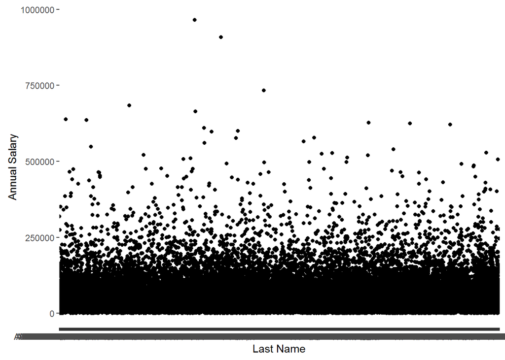

```r
ggplot(data = all.data, aes(x= `Last Name` , y=`Annual Salary` , ylab= "Salary", xlab= "Employees" )) + geom_point()
```

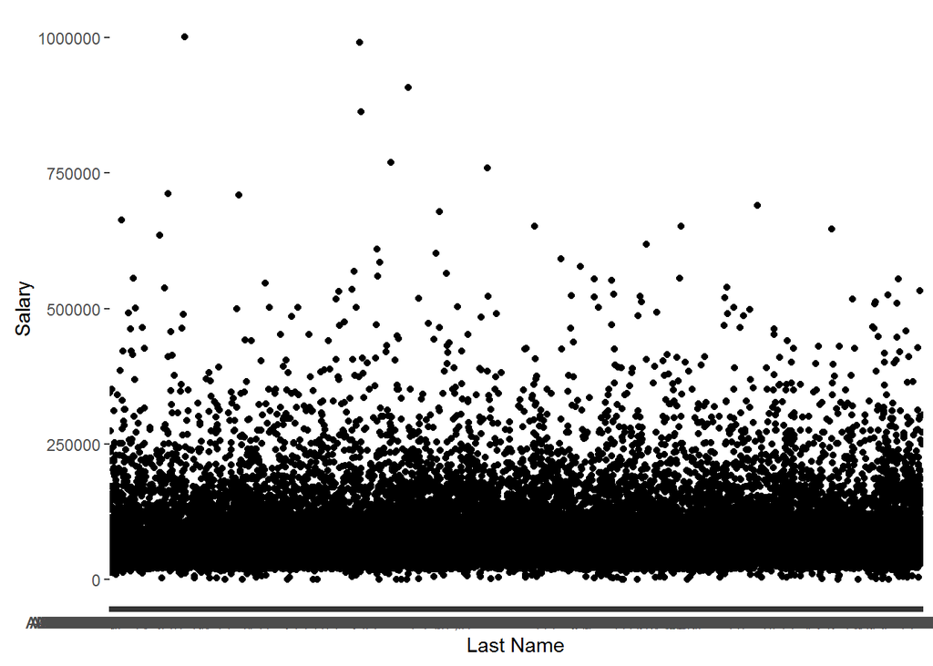

```r
all.data[,Salary := (sum(`Annual Salary`)), by = list(`First Name`, `Last Name`, MI)]
all.data <- unique(all.data[, list(University, `Last Name`, `First Name`, MI, sum.fte, Salary, type)])
all.data[sum.fte != 0.00, fte.salary := Salary / sum.fte]
ggplot(data = all.data, aes(x= `Last Name`, y=Salary , ylab= "Salary", xlab= "Employees" )) + geom_point()
```

## Splitting data by University

Now we want to organize the data to be comparable between New College and other Florida Universities, so we chunk the data into those classes.

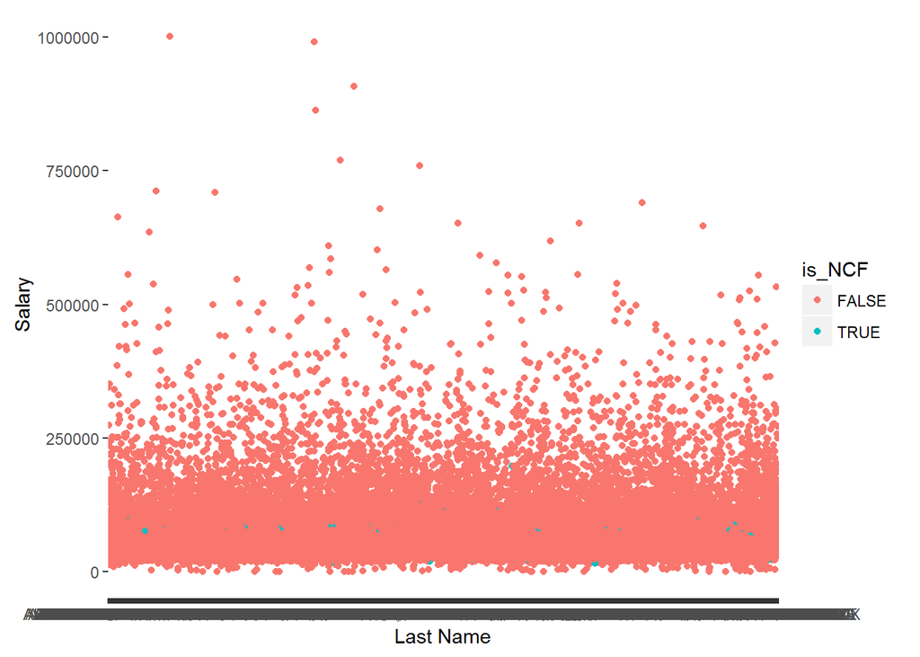

```r
all.data[, is_NCF := (University=='NCF')]
ggplot(data = all.data, aes(xlab = "Employees", x= `Last Name`, y=Salary ))  + geom_point(aes(colour= is_NCF))
```

Although we have colored the points based on whether or not they are New College, it is still impossible to see the points. Perhaps if we add some opacity and jitter to the plot.

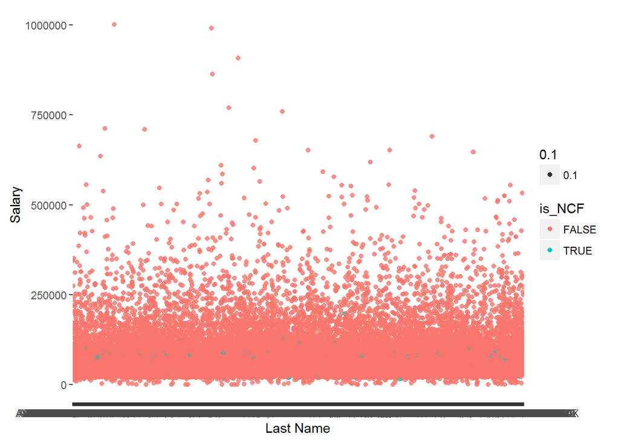

```r
ggplot(data = all.data, aes(xlab = "Employees", x= `Last Name`, y=Salary )) + geom_point(aes(colour=is_NCF, alpha = .1, solid = FALSE)) +geom_jitter(aes(colour=is_NCF, alpha = .1, solid = FALSE))
```

Opacity and jitter do not help us see the overall distribution compared to NCF very well, so lets try to split it by university.

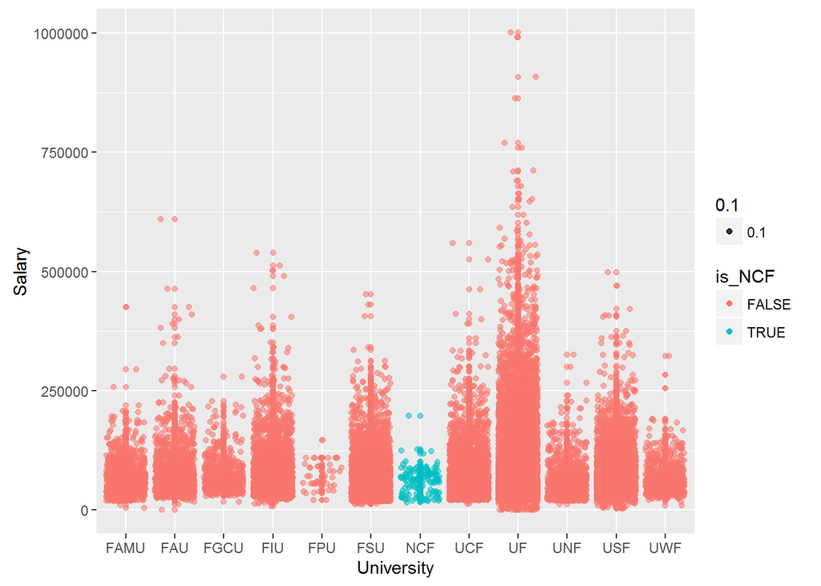

```r
ggplot(data = all.data, aes(xlab = "University", x= University, y=Salary )) + geom_point(aes(colour=is_NCF, alpha = .1, solid = FALSE)) + geom_jitter(aes(colour=is_NCF, alpha = .1, solid = FALSE))
```

We can immediately see the drastic difference in range for New College’s salaries compared to other universities and get some idea of the maginitudes and distributions However, the overall shape of the distributions are still hard to see like this, so lets see it before and after as a boxplots

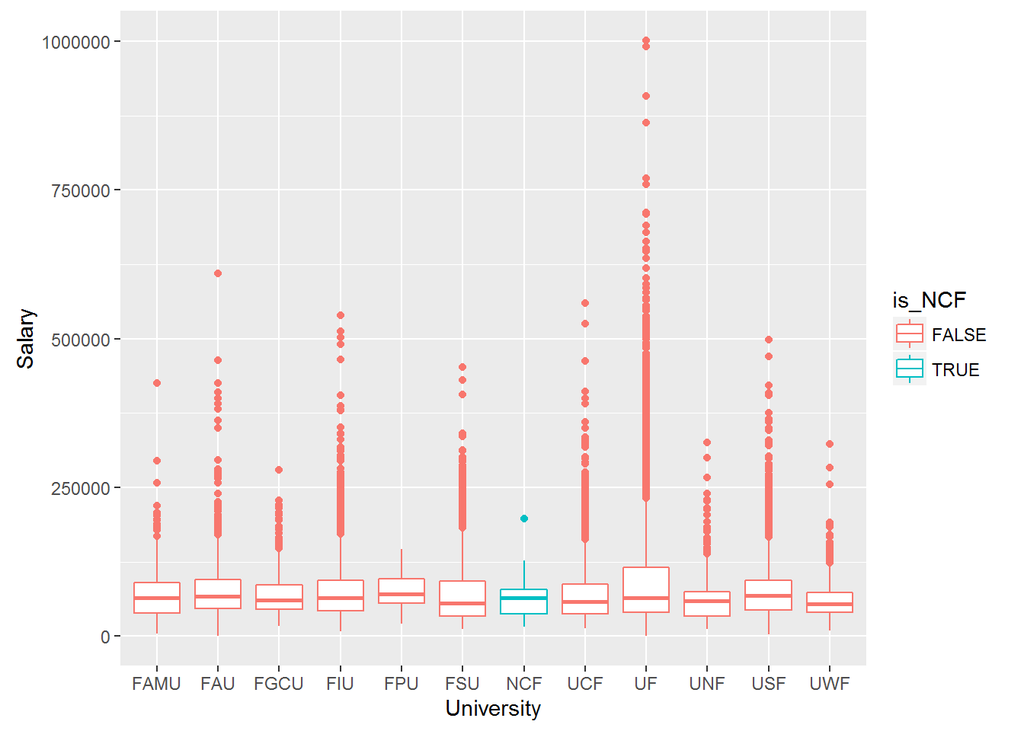

```r
ggplot(data = all.data, aes( x= University, y=Salary)) + geom_boxplot(aes( ylab = "Salary (in USD $)", colour=is_NCF))
```

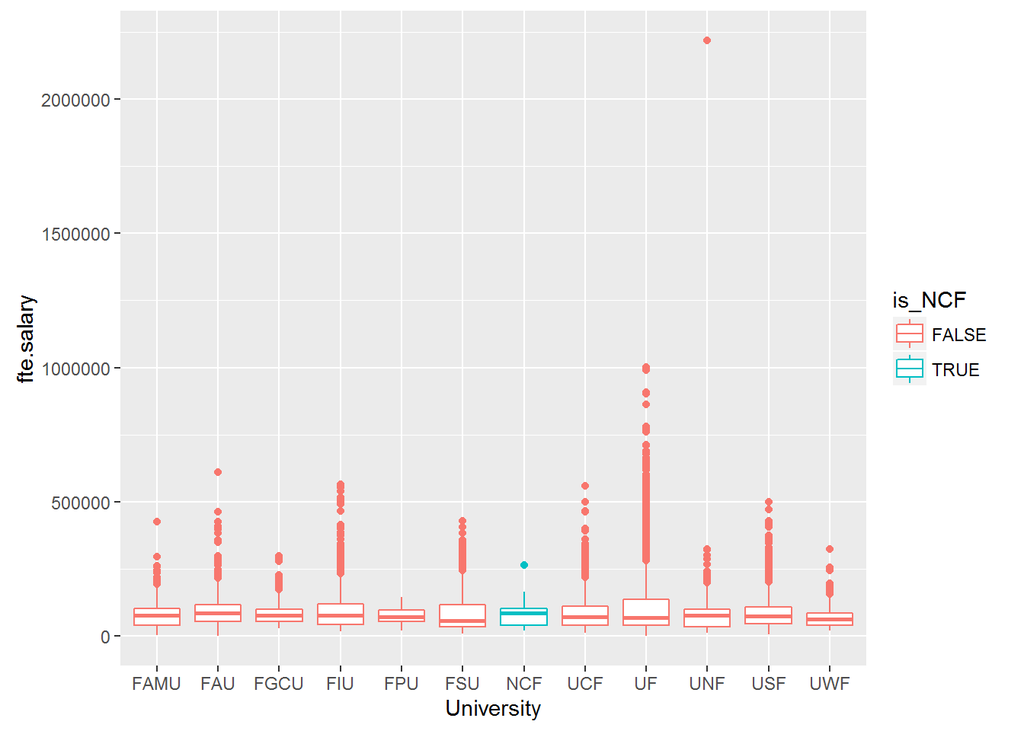

```r
ggplot(data = all.data, aes( x= University, y=fte.salary)) + geom_boxplot(aes( ylab = "FTE adjusted Salary (in USD $)", colour=is_NCF))
```

Salary adjusted for time (Salary / FTE) does not seem to show any major difference in distribution besides add more outliers. And y axis values become scaled down and compressed for the most part. Lets take another look, with violin plots this time.

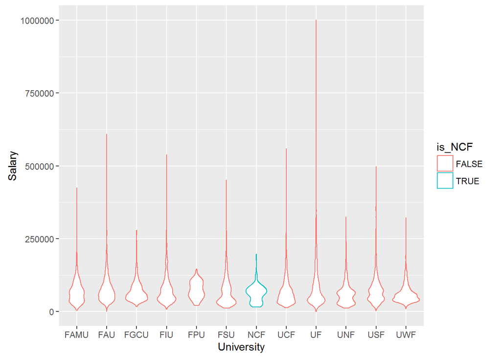

```r
ggplot(data = all.data, aes(xlab = "Universities", x= University, y=Salary, ylab = "Salary (in USD $)")) + geom_violin(aes(colour=is_NCF))
```

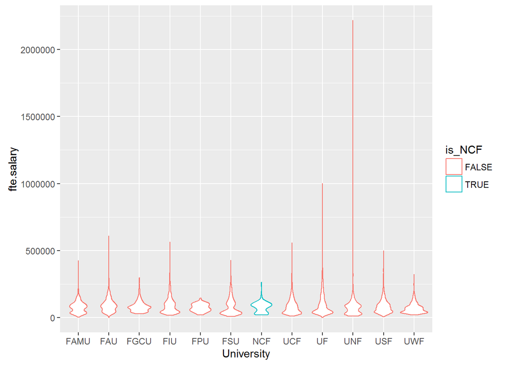

```r
ggplot(data = all.data, aes(  x= University, y=fte.salary)) + geom_violin(aes(xlab = "Universities", ylab = "FTE adjusted Salary (in USD $)",colour=is_NCF))
```

Now we wish to compare faculty and administration salaries, we can do this with facet_wrap() over the type coing we made.

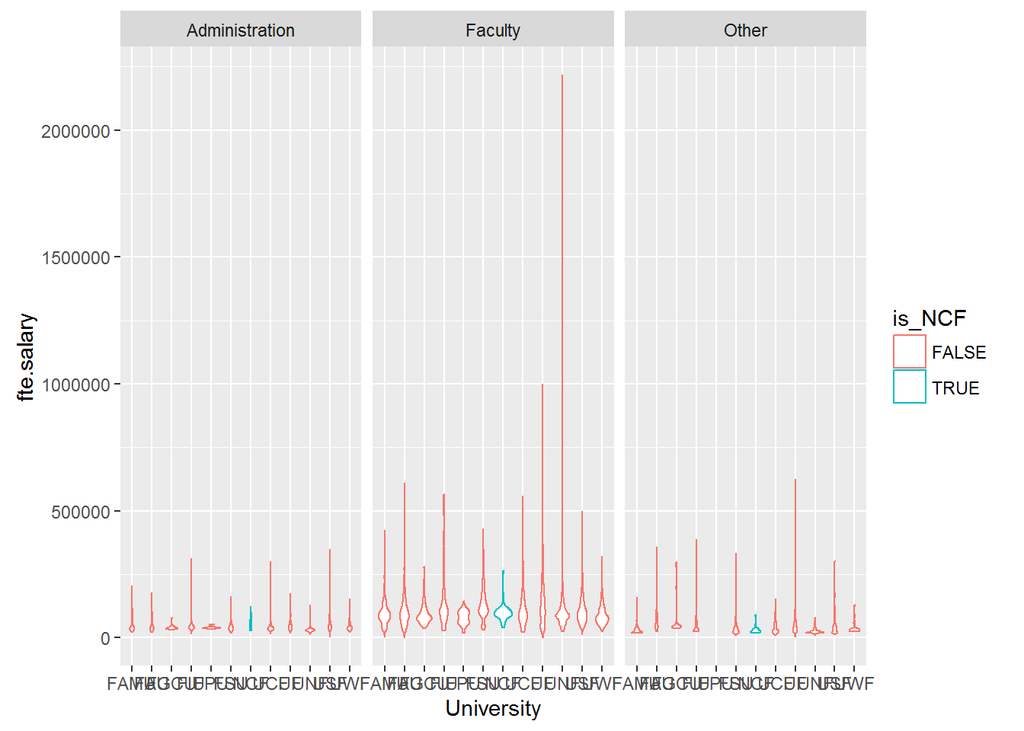

```r
ggplot(data = all.data, aes( x= University, y=fte.salary)) + geom_violin(aes(xlab = "Universities", ylab = "FTE adjusted Salary (in USD $)",colour=is_NCF)) +  facet_wrap(~type)
```

This is good, we can make out that the NCF distribution has a much lower variance than other universities, most of which have long tails and lots of upper outliers. It appears faculty usually make more than the administration for every school as well. Lets try to compare NCF against all others together as a single group.

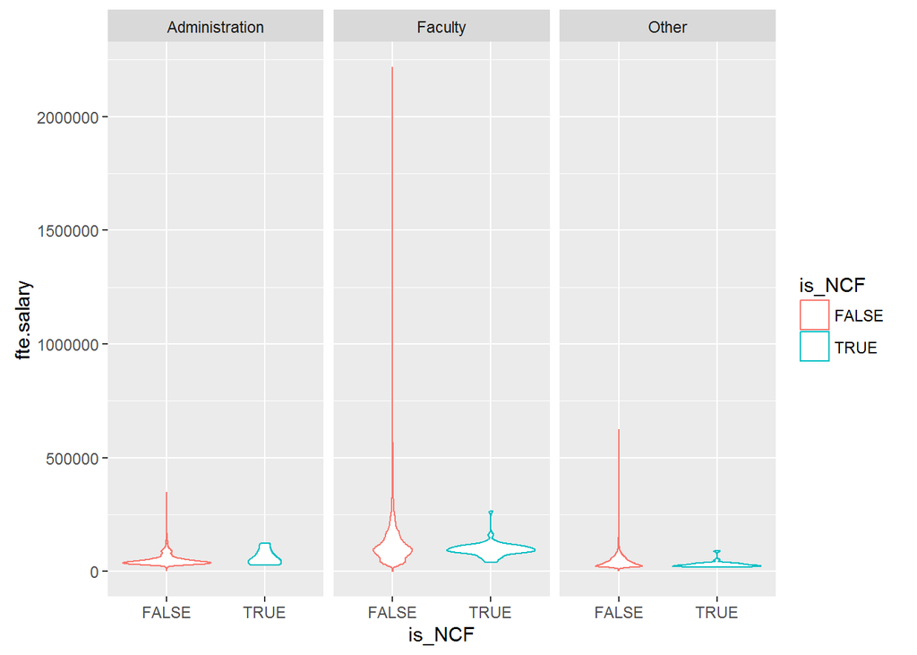

```r
ggplot(data = all.data, aes(xlab = "Universities", ylab = "FTE adjusted Salary (in USD $)", x= is_NCF, y=fte.salary)) + geom_violin(aes(colour=is_NCF)) + facet_wrap(~type)
```